# Datamations analysis for CHI 2021

2021-01-11

# 1 Load and clean data

```r
# read in clean data as produced by the (private) mturk_prod.Rmd script
df <- read_tsv("clean_data.tsv")
```

```r
# parse all timestamps
# compute time spent between survey intro page and submitted timestamp
# (note: name of "ts_is_same_dataset_start" might be a bit misleading,
# this was right after participants clicked continue on the consent form)
df <- df %>%
  #mutate(across(starts_with('ts_'), as.POSIXct)) %>%
  mutate(time_spent = difftime(as.POSIXct(ts_submitted_),
                               as.POSIXct(ts_is_same_dataset_start),
                               units = "min"))

# convert to pretty labels for conditions
df <- df %>%
  mutate(study = recode_factor(study, sanddance = "plot", tibble = "table"),
         condition = recode_factor(condition, static = "Saw only\nfinal X",
                                   stepthru = "Saw X-based\ndatamation"),
         condition = cap_first_letter(str_replace_all(condition, 'X',as.character(study))),
         study = sprintf('%s-based condition', str_to_title(study)))

PLOT_STUDY <- "Plot-based condition"
TABLE_STUDY <- "Table-based condition"
```

There were 1273 people who completed the experiment. All participants were required to have an approval rating of 99% or higher and to have completed at least 100 approved HITs prior to participating in this experiment.

# 2 Sanity checks

## 2.1 Randomization check

Randomization between static visualizations and datamations looks to be roughly balanced within each study.

```r
counts <- df %>%
  count(study, condition)

kable(counts)
```

[output not shown]

```r
counts %>%
  group_by(study) %>%
  do(tidy(chisq.test(.$n))) %>%
  kable()
```

| study | statistic | p.value | parameter | method |
| --- | --- | --- | --- | --- |
| Plot-based condition | 1.107345 | 0.2926599 | 1 | Chi-squared test for given probabilities |
| Table-based condition | 1.700885 | 0.1921723 | 1 | Chi-squared test for given probabilities |

## 2.2 Time spent on the experiment

We told participants that the experiment would take about 5-10 minutes and paid them $1.50 for completing it. The median time to complete the experiment across all participants was 6.81666666666667 minutes.

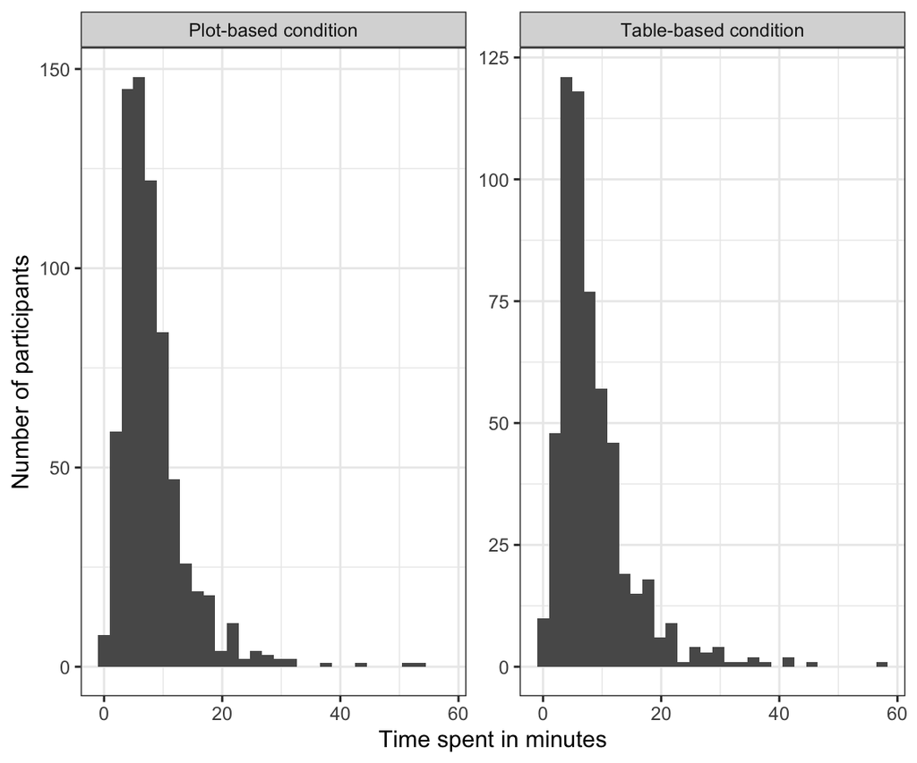

```r
ggplot(df, aes(x = time_spent)) +
  geom_histogram() +
  facet_wrap(~ study, scale = "free_y") +
  labs(x = "Time spent in minutes",
       y = "Number of participants")
```

```r
df %>%
  group_by(study) %>%
  summarize(median(time_spent)) %>%
  kable()
```

| study | median(time_spent) |
| --- | --- |
| Plot-based condition | 6.858333 mins |
| Table-based condition | 6.766667 mins |

# 3 Exclusions

Remove any participants who finished this experiment too quickly. As per our pre-registration, too quickly means anyone who is assigned to the static condition and completes the experiment in less than 45 seconds or anyone who is assigned to the stepthru datamation and completes the experiment in less than 90 seconds, which we based on pilot study completion times.

```r
nrow(df)
```

```
## [1] 1273
```

```r
df <- df %>%
  filter((grepl('final', condition, ignore.case = T) & time_spent > 45/60) |
         (grepl('datamation$', condition) & time_spent > 90/60))

nrow(df)
```

```
## [1] 1262
```

```r
df %>%
  count(study, condition)
```

```
## # A tibble: 4 x 3
##   study                 condition                         n
##   <chr>                 <chr>                         <int>
## 1 Plot-based condition  "Saw only\nfinal plot"          363
## 2 Plot-based condition  "Saw plot-based\ndatamation"    339
## 3 Table-based condition "Saw only\nfinal table"         294
## 4 Table-based condition "Saw table-based\ndatamation"   266
```

We are left with 1262 participants after exclusions.

# 4 Primary hypotheses

## 4.1 (Im)possibility that results are from the same dataset

### 4.1.1 Plots

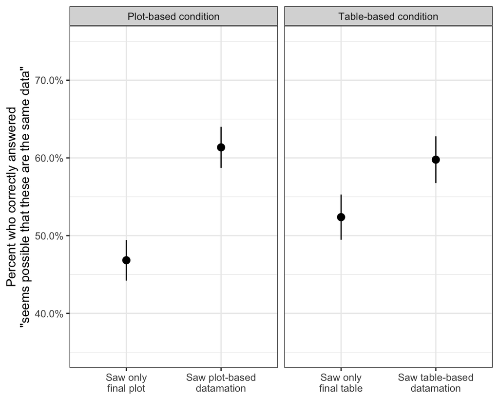

```r
plot_data <- df %>%
  group_by(study, condition) %>%
  summarize(n_total = n(),
            n_correct = sum(is_impossible_choice == "possible"),
            p = n_correct / n_total,
            se = sqrt(p * (1 - p) / n()))
ggplot(plot_data, aes(x = condition, y = p)) +
  geom_pointrange(aes(ymin = p - se, ymax = p + se)) +
  facet_wrap(~ study, scale = "free_x") +
  scale_y_continuous(label = percent, lim = c(0.35,0.75)) +
  labs(x = '',
       y = 'Percent who correctly answered\n"seems possible that these are the same data"')
```

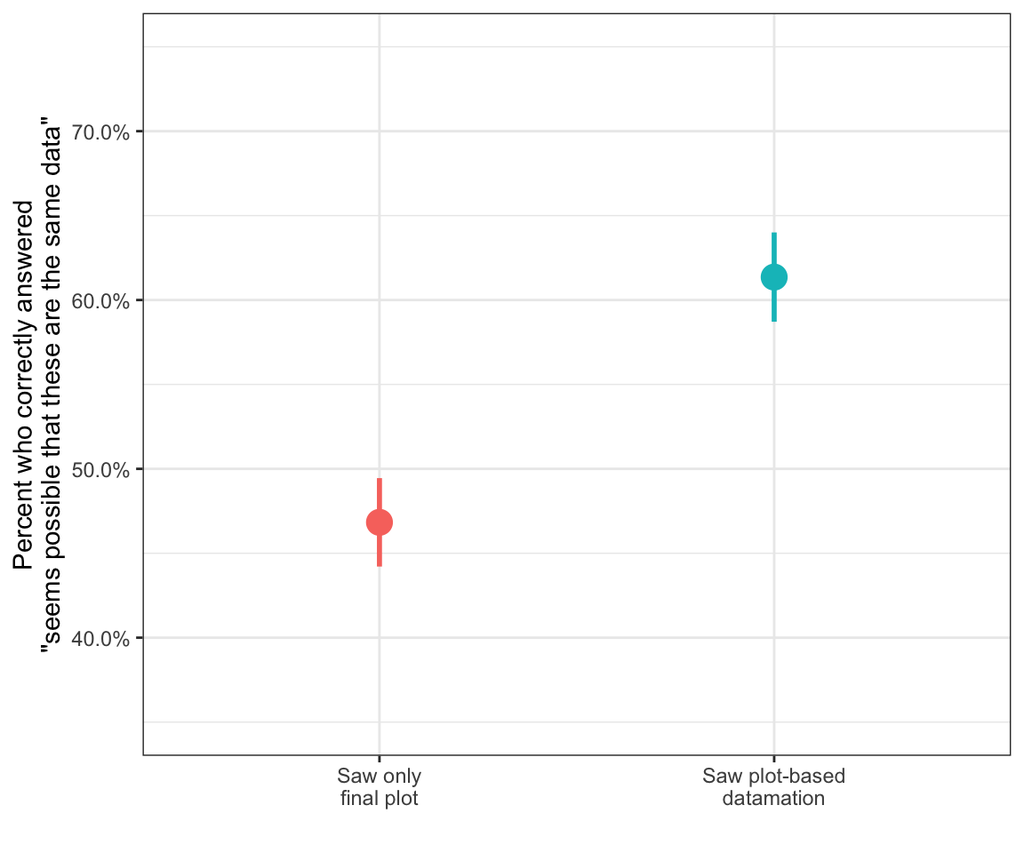

```r
  ggsave(filename = sprintf('%s/frac_correct_is_impossible_both_studies.pdf', figure_dir), width = 8, height = 4)

plot_data %>%
  filter(study == PLOT_STUDY) %>%
  ggplot(aes(x = condition, y = p, color = condition)) +
  geom_pointrange(aes(ymin = p - se, ymax = p + se), size = 1) +
  #facet_wrap(~ study, scale = "free_x") +
  scale_y_continuous(label = percent, lim = c(0.35,0.75)) +
  scale_color_discrete(guide = F) +
  labs(x = '',
       y = 'Percent who correctly answered\n"seems possible that these are the same data"')
```

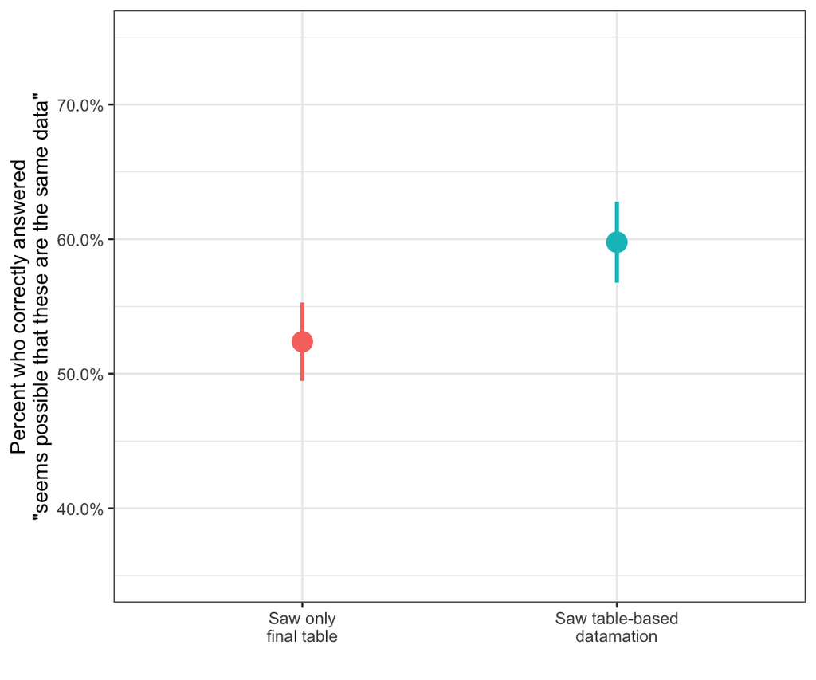

```r
ggsave(filename = sprintf('%s/frac_correct_is_impossible_plot_study.pdf', figure_dir), width = 4, height = 4)

plot_data %>%
  filter(study == TABLE_STUDY) %>%
  ggplot(aes(x = condition, y = p, color = condition)) +
  geom_pointrange(aes(ymin = p - se, ymax = p + se), size = 1) +
  #facet_wrap(~ study, scale = "free_x") +
  scale_y_continuous(label = percent, lim = c(0.35,0.75)) +
  scale_color_discrete(guide = F) +
  labs(x = '',
       y = 'Percent who correctly answered\n"seems possible that these are the same data"')
```

```r
ggsave(filename = sprintf('%s/frac_correct_is_impossible_table_study.pdf', figure_dir), width = 4, height = 4)
```

### 4.1.2 Significance tests

```r
plot_data %>%
  group_by(study) %>%
  do(tidy(prop.test(.$n_correct, .$n_total, alternative = "less", conf.level = 0.95))) %>%
  kable()
```

| study | estimate1 | estimate2 | statistic | p.value | parameter | conf.low | conf.high | method | alternative |
| --- | --- | --- | --- | --- | --- | --- | --- | --- | --- |
| Plot-based condition | 0.4683196 | 0.6135693 | 14.302465 | 0.0000778 | 1 | -1 | -0.0811754 | 2-sample test for equality of proportions with continuity correction | less |
| Table-based condition | 0.5238095 | 0.5977444 | 2.803877 | 0.0470183 | 1 | -1 | -0.0014992 | 2-sample test for equality of proportions with continuity correction | less |

```r
test_data_plot <- plot_data %>% filter(study == PLOT_STUDY)
test_results_plot <- prop.test(test_data_plot$n_correct, test_data_plot$n_total, alternative = "less", conf.level = 0.95)

test_data_table <- plot_data %>% filter(study == TABLE_STUDY)
test_results_table <- prop.test(test_data_table$n_correct, test_data_table$n_total, alternative = "less", conf.level = 0.95)
```

Test results for plot-based condition:

$$\chi^2(1, N = 702) = 14.3024652, p = 7.7830444\times 10^{-5}$$
$$z(702) = 3.78186, p = 7.7830444\times 10^{-5}$$

Test results for table-based condition:

$$\chi^2(1, N = 560) = 2.8038769, p = 0.0470183$$
$$z(560) = 1.6744781, p = 0.0470183$$

### 4.1.3 Effect size

```r
plot_data %>%
  group_by(study) %>%
  do(data.frame(cohens_h = ES.h(.$p[2], .$p[1]))) %>%
  kable()
```

| study | cohens_h |
| --- | --- |
| Plot-based condition | 0.2925419 |
| Table-based condition | 0.1491187 |

## 4.2 Explanation resolving the apparent paradox

### 4.2.1 Plots

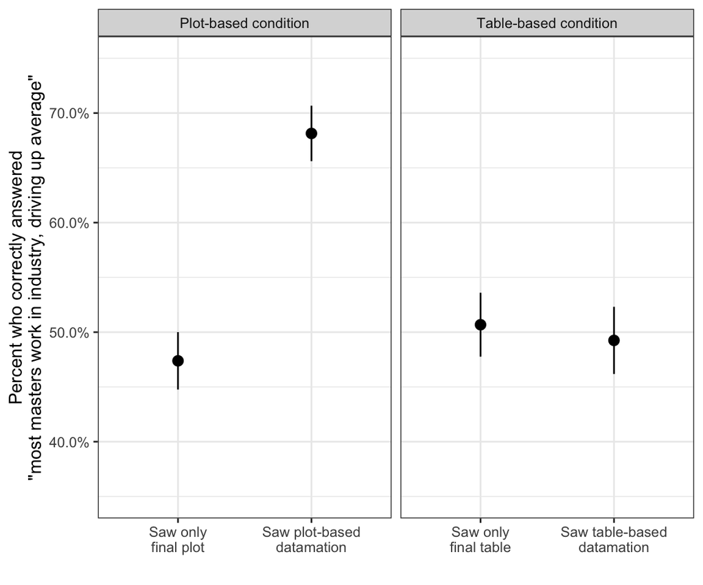

```r
plot_data <- df %>%
  group_by(study, condition) %>%
  summarize(n_total = n(),
            n_correct = sum(explanation_text == "more-masters-in-industry"),
            p = n_correct / n_total,
            se = sqrt(p * (1 - p) / n()))
ggplot(plot_data, aes(x = condition, y = p)) +
  geom_pointrange(aes(ymin = p - se, ymax = p + se)) +
  facet_wrap(~ study, scale = "free_x") +
  scale_y_continuous(label = percent, lim = c(0.35,0.75)) +
  labs(x = '',
       y = 'Percent who correctly answered\n"most masters work in industry, driving up average"')
```

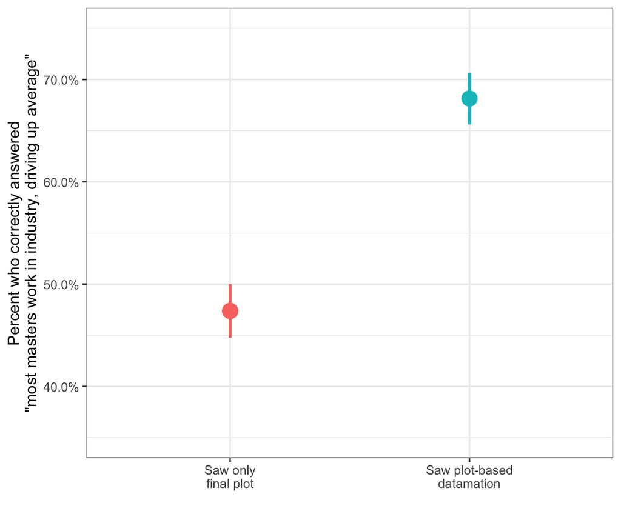

```r
ggsave(filename = sprintf('%s/frac_correct_explanation_of_paradox_both_studies.pdf', figure_dir), width = 8, height = 4)

plot_data %>%
  filter(study == PLOT_STUDY) %>%
  ggplot(aes(x = condition, y = p, color = condition)) +
  geom_pointrange(aes(ymin = p - se, ymax = p + se), size = 1) +
  #facet_wrap(~ study, scale = "free_x") +
  scale_y_continuous(label = percent, lim = c(0.35,0.75)) +
  scale_color_discrete(guide = F) +
  labs(x = '',
       y = 'Percent who correctly answered\n"most masters work in industry, driving up average"')
```

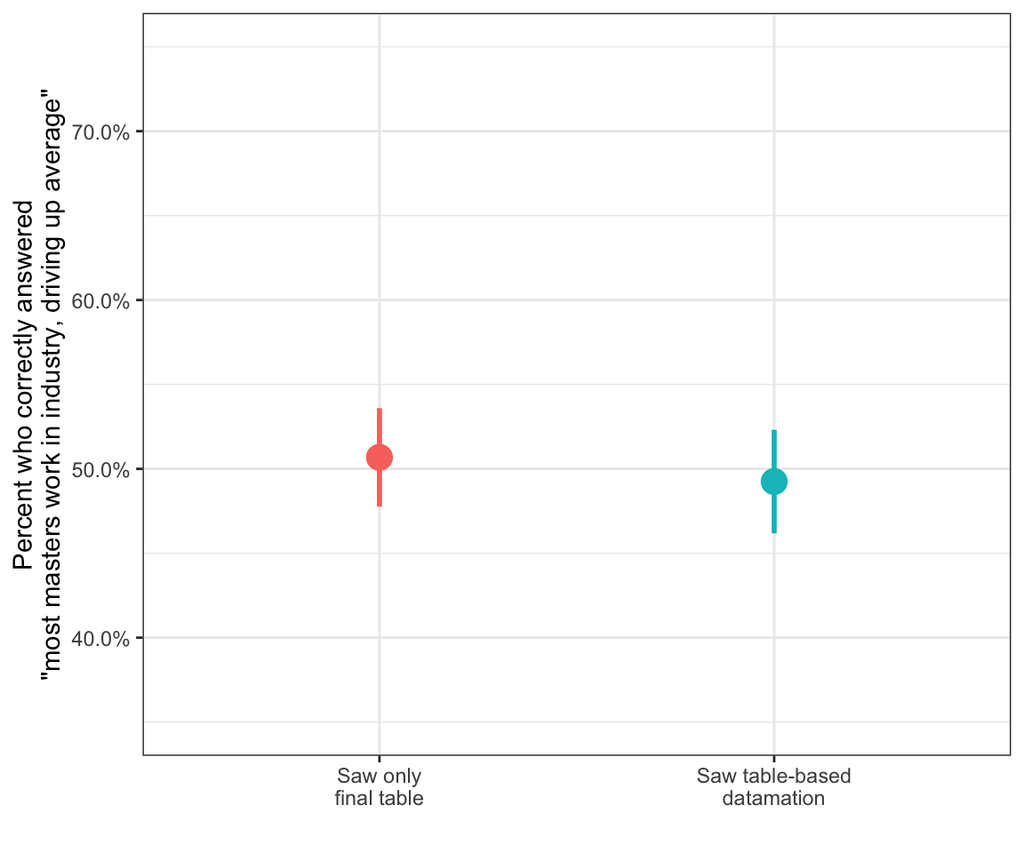

```r
ggsave(filename = sprintf('%s/frac_correct_explanation_of_paradox_plot_study.pdf', figure_dir), width = 4, height = 4)

plot_data %>%
  filter(study == TABLE_STUDY) %>%
  ggplot(aes(x = condition, y = p, color = condition)) +
  geom_pointrange(aes(ymin = p - se, ymax = p + se), size = 1) +
  #facet_wrap(~ study, scale = "free_x") +
  scale_y_continuous(label = percent, lim = c(0.35,0.75)) +
  scale_color_discrete(guide = F) +
  labs(x = '',
       y = 'Percent who correctly answered\n"most masters work in industry, driving up average"')
```

```r
ggsave(filename = sprintf('%s/frac_correct_explanation_of_paradox_table_study.pdf', figure_dir), width = 4, height = 4)
```

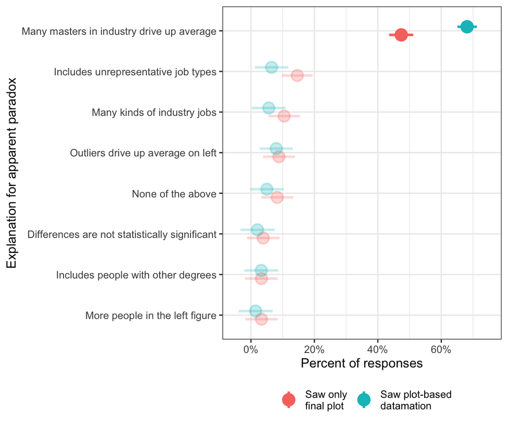

```r
plot_data_all_choices <- df %>%
  mutate(pretty_explanation_text = recode_factor(explanation_text,
                                          "left-more-than-right" = "More people in the left figure",
                                          "left-not-stat-sig" = "Differences are not statistically significant",
                                          "many-industry-on-right" = "Many kinds of industry jobs",
                                          "more-masters-in-industry" = "Many masters in industry drive up average",
                                          "mystery-work-on-left" = "Includes unrepresentative job types",
                                          "non-grads-on-right" = "Includes people with other degrees",
                                          "none-of-the-above" = "None of the above",
                                          "outliers-drive-up-masters" = "Outliers drive up average on left")) %>%
  group_by(study, condition) %>%
  count(explanation_text, pretty_explanation_text) %>%
  mutate(p = n / sum(n),
         se = sqrt(p * (1-p) / n))

plot_data_all_choices %>%
  filter(study == PLOT_STUDY) %>%
  mutate(pretty_explanation_text = reorder(pretty_explanation_text, p)) %>%
  ggplot(aes(x = pretty_explanation_text, y = p, color = condition)) +
  geom_pointrange(aes(ymin = p - se, ymax = p + se, alpha = explanation_text == "more-masters-in-industry"), position = position_dodge(width = 0.4), size = 1) +
  scale_y_continuous(label = percent, lim = c(-0.05, 0.75)) +
  scale_alpha_manual(values = c(0.25, 1.0), guide = F) +
  labs(x = 'Explanation for apparent paradox',
       y = 'Percent of responses') +
  coord_flip() +
  theme(legend.title = element_blank(),
        legend.position = "bottom")
```

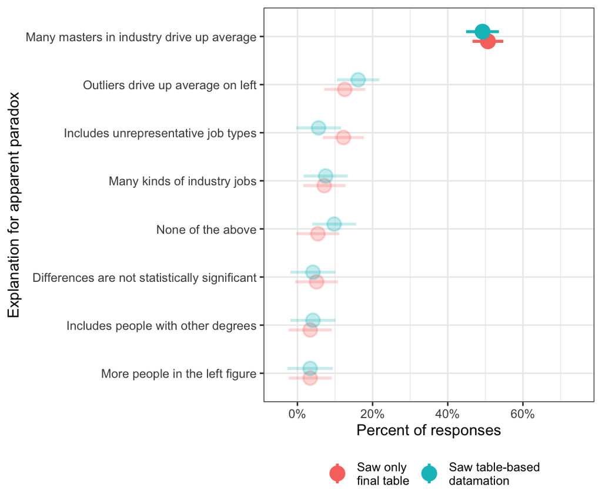

```r
ggsave(filename = sprintf('%s/explanation_of_paradox_plot_study.pdf', figure_dir), width = 6, height = 4)


plot_data_all_choices %>%
  filter(study == TABLE_STUDY) %>%
  mutate(pretty_explanation_text = reorder(pretty_explanation_text, p)) %>%
  ggplot(aes(x = pretty_explanation_text, y = p, color = condition)) +
  geom_pointrange(aes(ymin = p - se, ymax = p + se, alpha = explanation_text == "more-masters-in-industry"), position = position_dodge(width = 0.4), size = 1) +
  scale_y_continuous(label = percent, lim = c(-0.05, 0.75)) +
  scale_alpha_manual(values = c(0.25, 1.0), guide = F) +
  labs(x = 'Explanation for apparent paradox',
       y = 'Percent of responses') +
  coord_flip() +
  theme(legend.title = element_blank(),
        legend.position = "bottom")
```

```r
ggsave(filename = sprintf('%s/explanation_of_paradox_table_study.pdf', figure_dir), width = 6, height = 4)
```

### 4.2.2 Significance tests

```r
plot_data %>%
  group_by(study) %>%
  do(tidy(prop.test(.$n_correct, .$n_total, alternative = "less", conf.level = 0.95))) %>%
  kable()
```

| study | estimate1 | estimate2 | statistic | p.value | parameter | conf.low | conf.high | method | alternative |
| --- | --- | --- | --- | --- | --- | --- | --- | --- | --- |
| Plot-based condition | 0.4738292 | 0.6814159 | 30.0502995 | 0.0000000 | 1 | -1 | -0.1448112 | 2-sample test for equality of proportions with continuity correction | less |
| Table-based condition | 0.5068027 | 0.4924812 | 0.0644468 | 0.6001996 | 1 | -1 | 0.0874895 | 2-sample test for equality of proportions with continuity correction | less |

```r
test_data_plot <- plot_data %>% filter(study == PLOT_STUDY)
test_results_plot <- prop.test(test_data_plot$n_correct, test_data_plot$n_total, alternative = "less", conf.level = 0.95)

test_data_table <- plot_data %>% filter(study == TABLE_STUDY)
test_results_table <- prop.test(test_data_table$n_correct, test_data_table$n_total, alternative = "less", conf.level = 0.95)
```

Test results for plot-based condition:

$$\chi^2(1, N = 702) = 30.0502995, p = 2.1049176\times 10^{-8}$$
$$z(702) = 5.4818153, p = 2.1049176\times 10^{-8}$$

Test results for table-based condition:

$$\chi^2(1, N = 560) = 0.0644468, p = 0.6001996$$
$$z(560) = 0.2538638, p = 0.6001996$$

### 4.2.3 Effect size

```r
plot_data %>%
  group_by(study) %>%
  do(data.frame(cohens_h = ES.h(.$p[2], .$p[1]))) %>%
  kable()
```

| study | cohens_h |
| --- | --- |
| Plot-based condition | 0.4236706 |
| Table-based condition | -0.0286440 |

# 5 Other analyses

## 5.1 Preference for datamations in the future

# 6 Plots

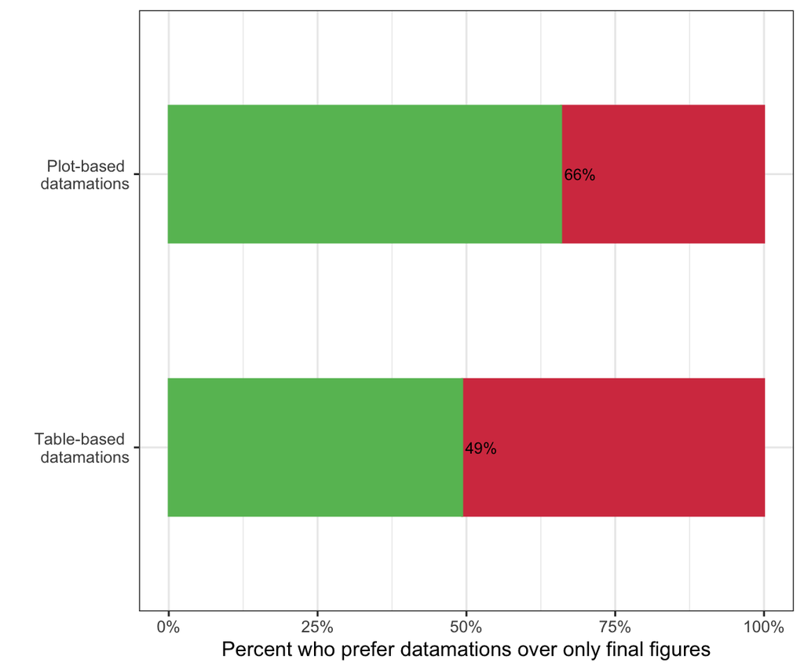

```r
plot_data <- df %>%
  filter(!is.na(future_opt)) %>%
  mutate(study = fct_rev(gsub('condition', '\ndatamations', study))) %>%
  group_by(study) %>%
  count(future_opt) %>%
  mutate(frac = n / sum(n))

ggplot(plot_data, aes(x = study, y = frac)) +
  #geom_pointrange(aes(ymin = p - se, ymax = p + se)) +
  #facet_wrap(~ study, scale = "free_x") +
  geom_bar(aes(color = future_opt, fill = future_opt), stat = "identity", width = 0.5) +
  scale_y_continuous(label = percent, lim = c(0,1)) +
  labs(x = '',
       y = 'Percent who prefer datamations over only final figures') +
  theme(legend.position = "none",
        #panel.grid.major = element_blank(),
        #panel.grid.minor = element_blank(),
        #panel.border = element_blank(),
        #axis.ticks = element_blank(),
        #axis.title.x=element_blank(),
        #axis.text.x=element_blank(),
        #axis.ticks.x=element_blank()
        ) +
  scale_color_manual(values = c('#d53e4f', '#66bd63')) +
  scale_fill_manual(values = c('#d53e4f', '#66bd63')) +
  coord_flip() +
  geom_text(data = filter(plot_data, future_opt == "static_ani"),
            aes(x = study, y = frac, label = sprintf('%0.f%%', frac*100)),
            hjust = -0.1, size = 3)
```

```r
ggsave(filename = sprintf('%s/frac_prefer_datamations_in_future.pdf', figure_dir), width = 6, height = 2)
```